# Visualisation and Imputation of Missing Values

July 2017

## Outline / R Package

- Content:
  - Tools for visualization of missing data structures (and imputed values)
  - Tools for imputation
- Current CRAN version 4.7.0
- Development version and issue tracking on github https://github.com/statistikat/VIM
- This presentation and the R code https://github.com/alexkowa/VIM_ISI2017
- [JSS paper on imputation of missing values with VIM, Kowarik, Templ](https://www.jstatsoft.org/article/view/v074i07)
- [Advances in Data Analysis and Classification paper on visualization with VIM, Templ, Alfons, Filzmoser](https://www.researchgate.net/publication/226283718_Exploring_incomplete_data_using_visualization_techniques)

## Visualisation of Missing Data

- Always important: knowledge about the structure of missing values. Visualisation vs statistical tests.
- literature with focus on visualization of missing data is sparse
- only a few visualization tools missing data
- R package VIM supports the visualization (also with a GUI).

## Aggregation Plots

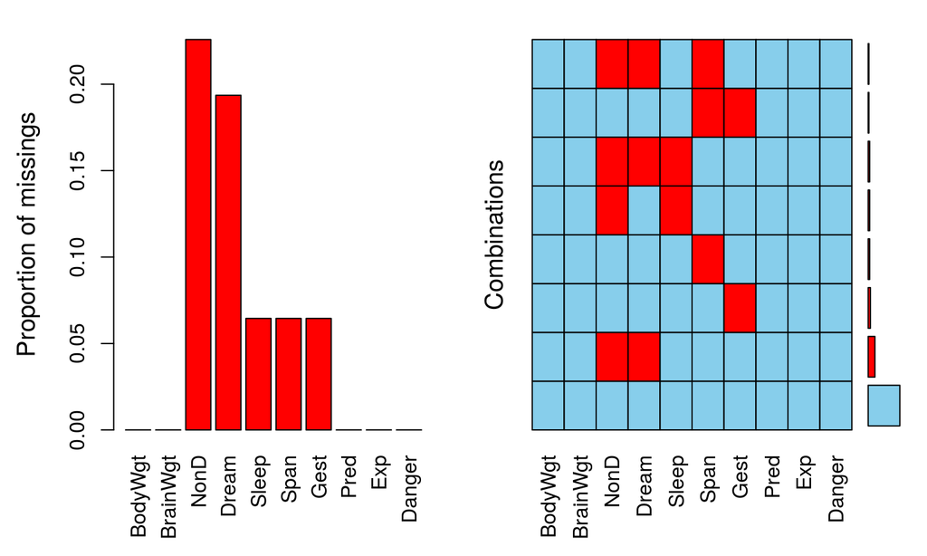

```r
aggr(sleep)
```

## Missing Values in Matrix Form

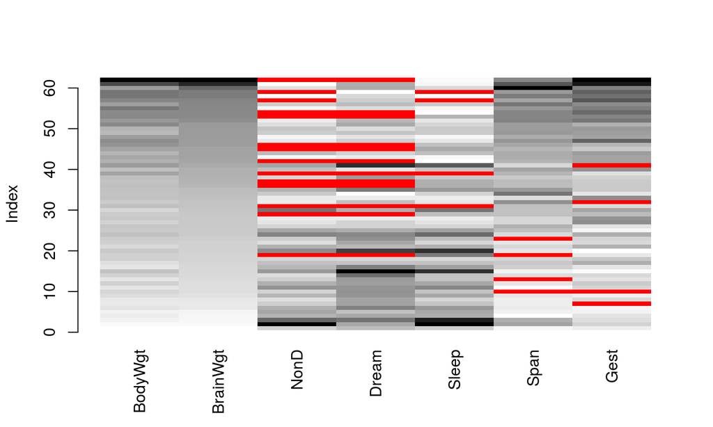

```r
matrixplot(x, sortby = "BrainWgt")
```

## Univariate Plots

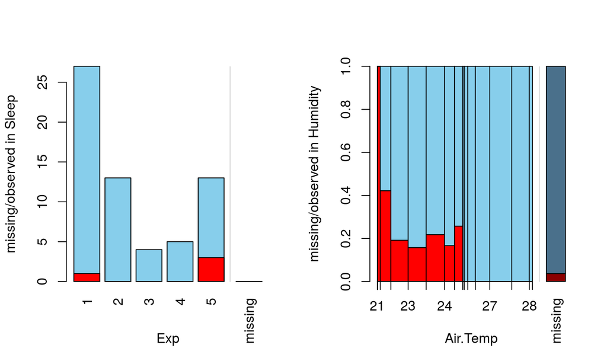

```r
par(mfrow=c(1,2)); histMiss(x2); spineMiss(x3)
```

## Bivariate Plots

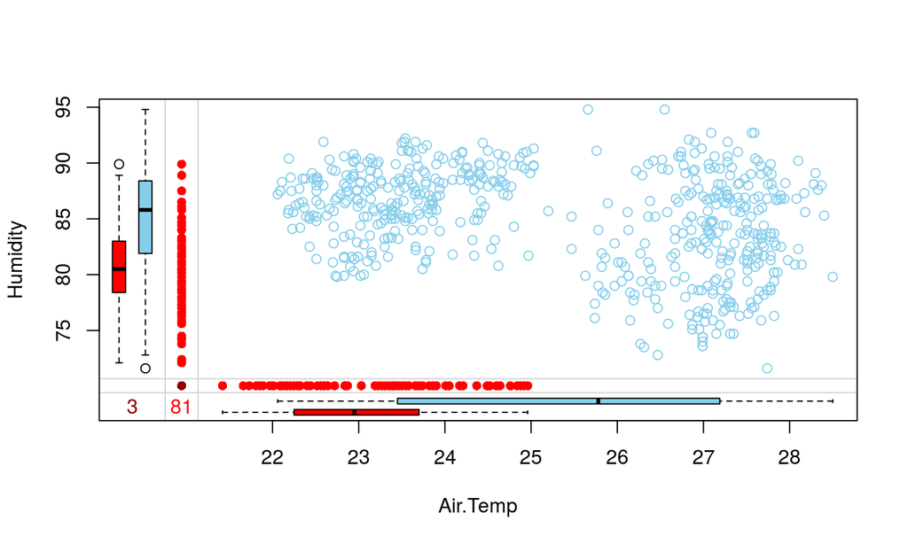

```r
marginplot(x3)
```

## Multivariate Plots

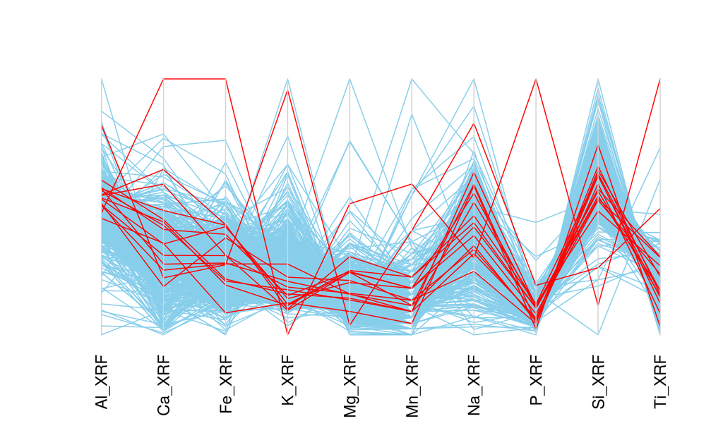

```r
parcoordMiss(x4,plotvars=2:11, interactive = FALSE)
```

## Multiple Plots

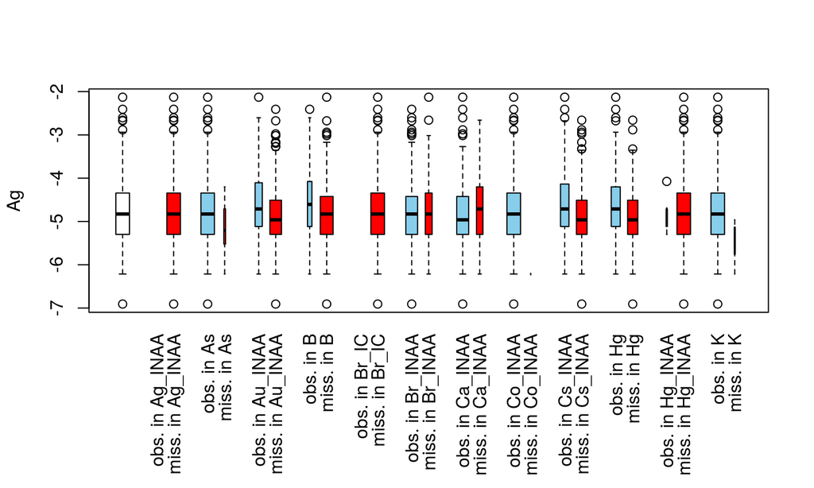

```r
pbox(x5)
```

## Donor Imputation - hotdeck

- Random (within group)
- Sequential (within group)

```r
hotdeck(data, variable = NULL, ord_var = NULL,
  domain_var = NULL, makeNA = NULL, NAcond = NULL,
  impNA = TRUE, donorcond = NULL, imp_var = TRUE,
  imp_suffix = "imp")
```

- *data* - data.frame
- *variable* - variables to be imputed
- *ord_var* - variables to sort by
- *domain_var* - variables to build imputation classes
- a random sort variable is always be added

## Donor Imputation - kNN

- kNN imputation based on an extended Gower distance
- different (customized/weighted) possibilities for the aggregation step
- Weighting of distance variables

```r
kNN(data, variable=colnames(data), metric=NULL, k=5,
    dist_var=colnames(data),weights=NULL, numFun = median,
    catFun=maxCat,makeNA=NULL,NAcond=NULL, impNA=TRUE,
    donorcond=NULL,mixed=vector(),mixed.constant=NULL,trace=FALSE,
    imp_var=TRUE,imp_suffix="imp",addRandom=FALSE,useImputedDist=TRUE,
    weightDist=FALSE)
```

- *dist_var* - variables used for distance combination
- *weights* - weights for distance computation
- *numFun*, *catFun* - aggregation function for numerical or categorical target variables (*sampleCat*, *maxCat*).
- *addRandom* - add a random variable to the distance computation (very low weight)

## Donor Imputation - matchImpute

Random within groups imputation, grouping variables are dropped sequentially in case all values are missing in a group.

```r
matchImpute(data,
  variable = colnames(data)[!colnames(data) %in% match_var],
  match_var, imp_var = TRUE, imp_suffix = "imp")
```

- *match_var* variables to build groups

## Iterative (Robust) Regression Imputation (1)

```r
irmi(x, eps = 5, maxit = 100, mixed = NULL,
  mixed.constant = NULL, count = NULL, step = FALSE ,
  robust = FALSE , takeAll = TRUE, noise = TRUE,
  noise.factor = 1, force = FALSE , robMethod = "MM",
  force.mixed = TRUE, mi = 1, addMixedFactors = FALSE ,
  trace = FALSE , init.method = "kNN")
```

- *robust* - robust or non-robust
- *step* - *stepAIC* in every iteration
- *mixed* - column indices of semi-continuous variables
- *count* - column indices of count variables (Poisson)
- *noise* - add a random error to the imputed value
- *mi* - number of imputations \(\Rightarrow\) multiple imputation

## Imputation Benchmarking (1)

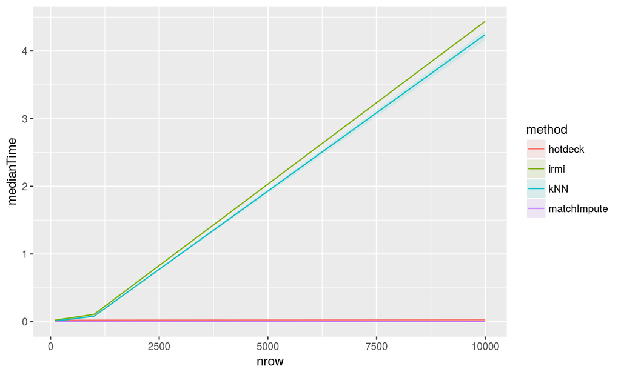

## Imputation Benchmarking (2)

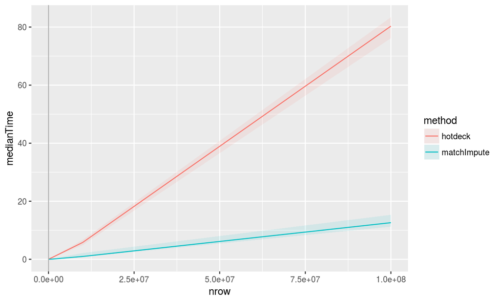

## Iterative Robust Regression Imputation (2)

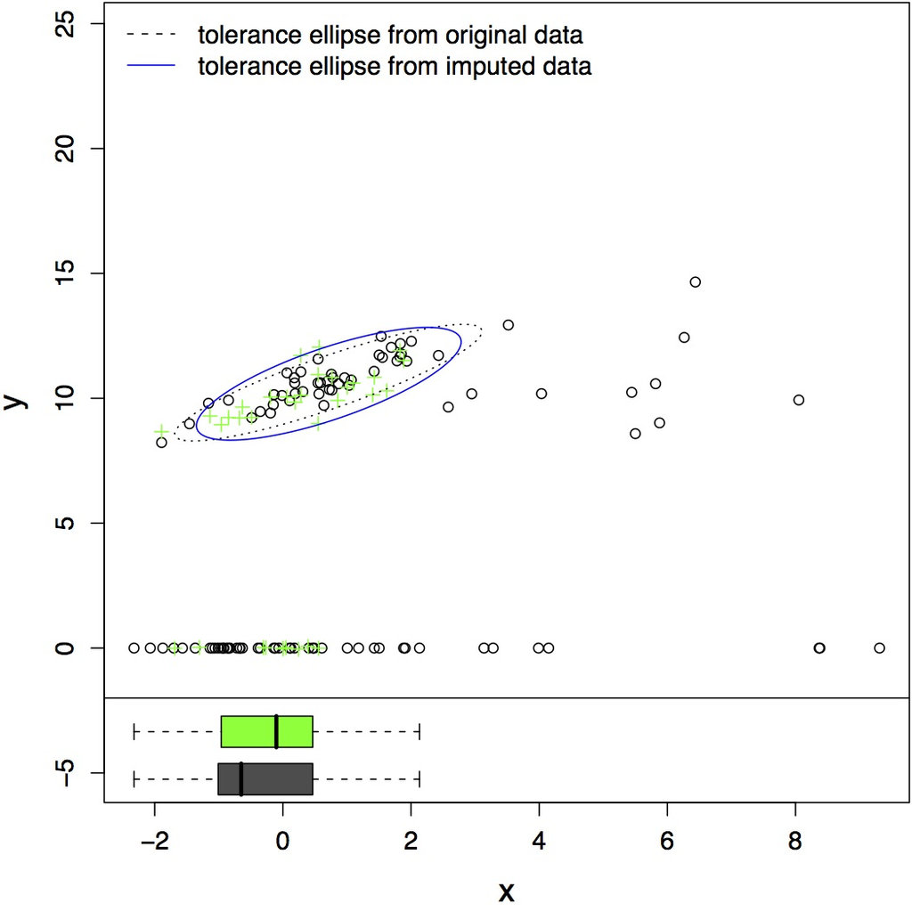

## One more thing: simputation

- Great package by Mark van der Loo
- A lot of different imputation methods including methods kNN and hotdeck from VIM

```r
sleepImp <- sleep %>% hotdeck(variable="NonD",domain_var="Danger") %>%
  kNN(variable="Dream",dist_var=c("BodyWgt","BrainWgt"))

sleepImp <- sleep %>% impute_shd( NonD~Danger,backend="VIM") %>%
  impute_knn(Dream~BodyWgt+BrainWgt, backend="VIM")
```

## Thank you

Feedback always welcome:

- alexander.kowarik@statistik.gv.at
- https://github.com/statistikat/VIM
- [Twitter: Alexkvienna](https://twitter.com/Alexkvienna)